# Empirical Atlas Richness and Turnover

WM

2026-06-10

## Overview

This report uses empirical atlas presences from the raw occurrence matrix, not HMSC predictions. The saved model-input files are used only to define the survey rows and retained species for each coverage filter.

First, the analysis is shown for the `Good/Fair` coverage set, which matches the current model input. Then the same analysis is repeated for `Good` coverage only, so we can see whether stricter sampling coverage changes the spatial richness, delta richness, species-level turnover, and guild-level patterns.

Sampling-effort estimates are only available for Atlas 1 and Atlas 2. For Atlas 3, the visualisations therefore include all available Atlas 3 sites from the preprocessed atlas data rather than applying a `Good` or `Fair` effort filter. In the shared-site analyses, a site is retained only if it appears in all three atlas periods after applying the Atlas 1/2 coverage filter and the unfiltered Atlas 3 site set.

All richness maps count observed atlas presences for retained species. Delta maps and turnover summaries use only grid cells present in all three atlas periods within each coverage filter.

Species-level change classes are based on the change in the proportion of shared grid cells occupied by each species. A species is classified as `Increase` when the later atlas occupies at least `0.10` more of the shared grid-cell set than the earlier atlas, `Decrease` when it occupies at least `0.10` less, and `Stable` otherwise. In plain terms, this is a 10 percentage-point threshold in occupied shared grid cells.

## Good/Fair Coverage

This section uses the `Good/Fair` retained survey rows and species pool from the current model input. Richness and turnover values are recalculated from the raw atlas occurrence matrix.

For Atlas 3, this section includes all available Atlas 3 sites because there is no Atlas 3 sampling-effort table to separate `Good` from `Fair` coverage.

### Richness Across Good/Fair Sites

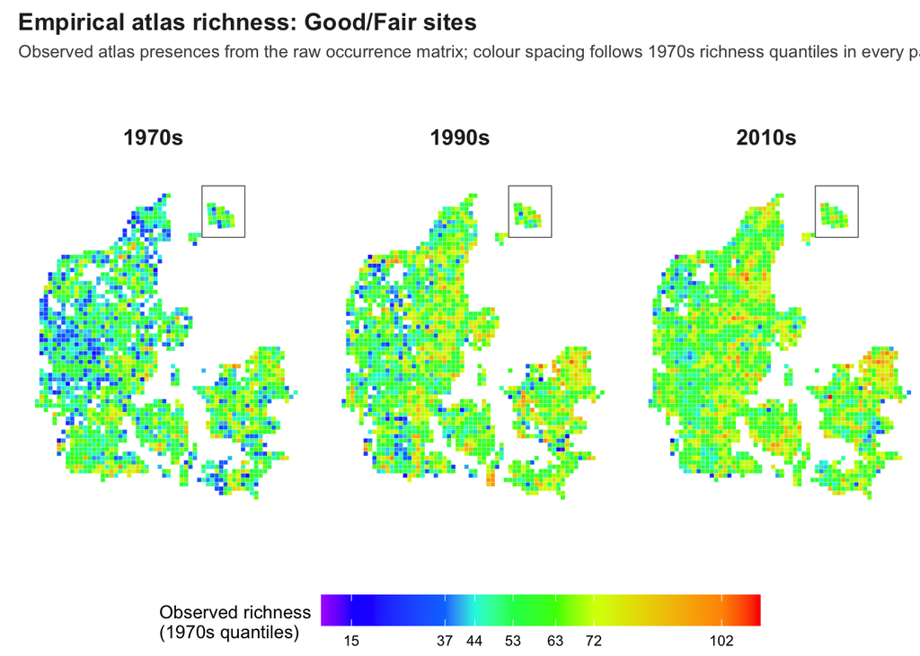

### Richness On Shared Good/Fair Sites

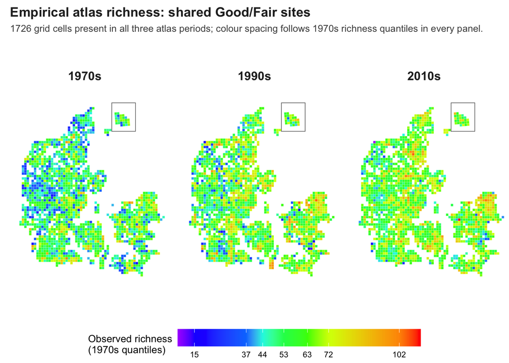

### Delta Richness On Shared Good/Fair Sites

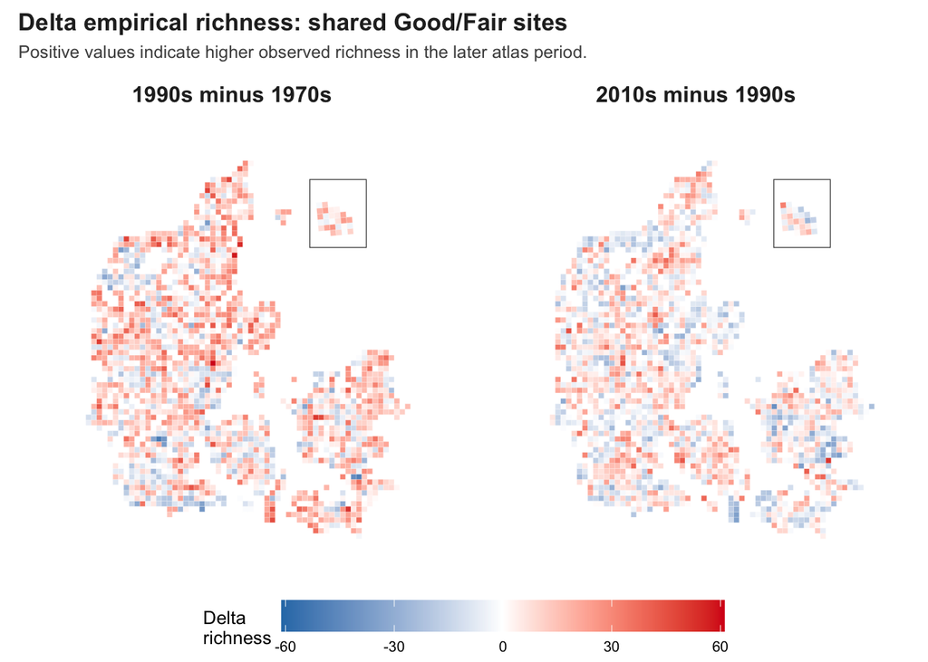

### Species-Level Changes

For this `Good/Fair` analysis, the 10 percentage-point rule corresponds to about 173 shared grid cells.

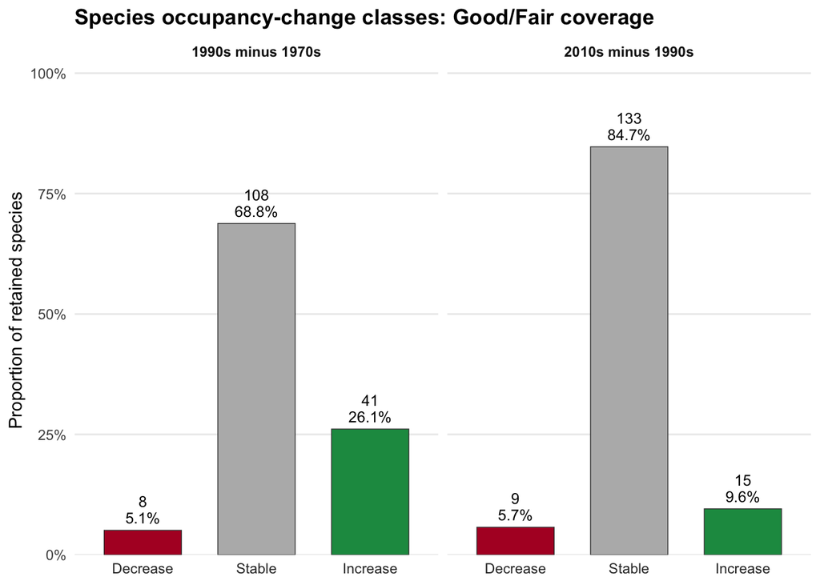

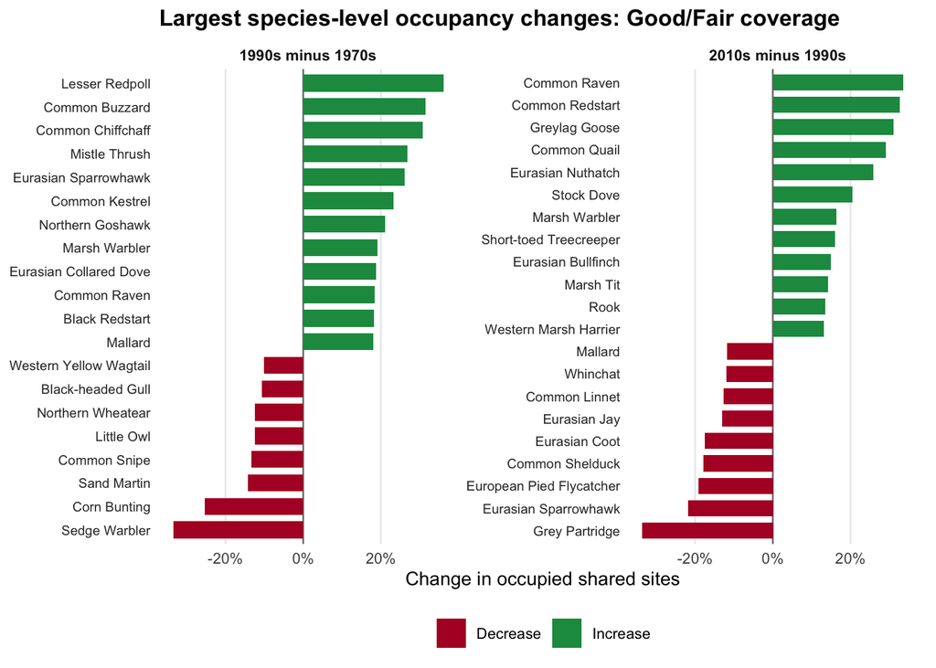

### Foraging-Guild Changes

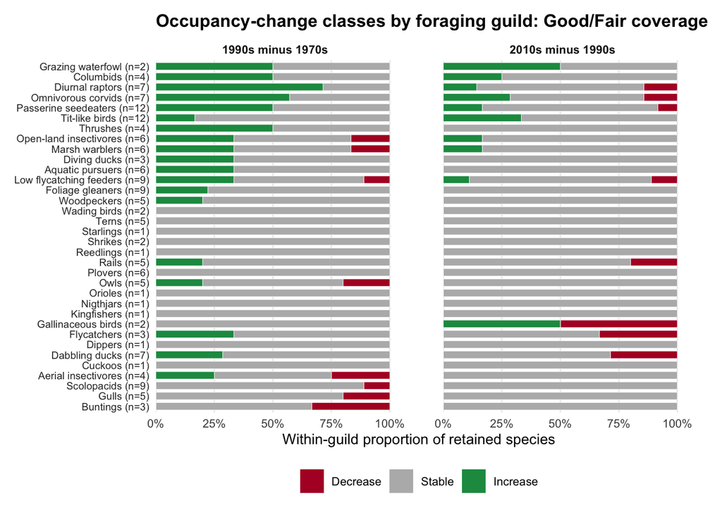

## Good Coverage Only

This section repeats the same empirical atlas analysis using only the `Good` coverage retained survey rows and species pool. This is the stricter coverage check against the `Good/Fair` patterns above.

As above, the `Good` coverage filter applies to Atlas 1 and Atlas 2 only. Atlas 3 includes all available Atlas 3 sites because sampling-effort estimates are not available for that period.

### Richness Across Good Sites

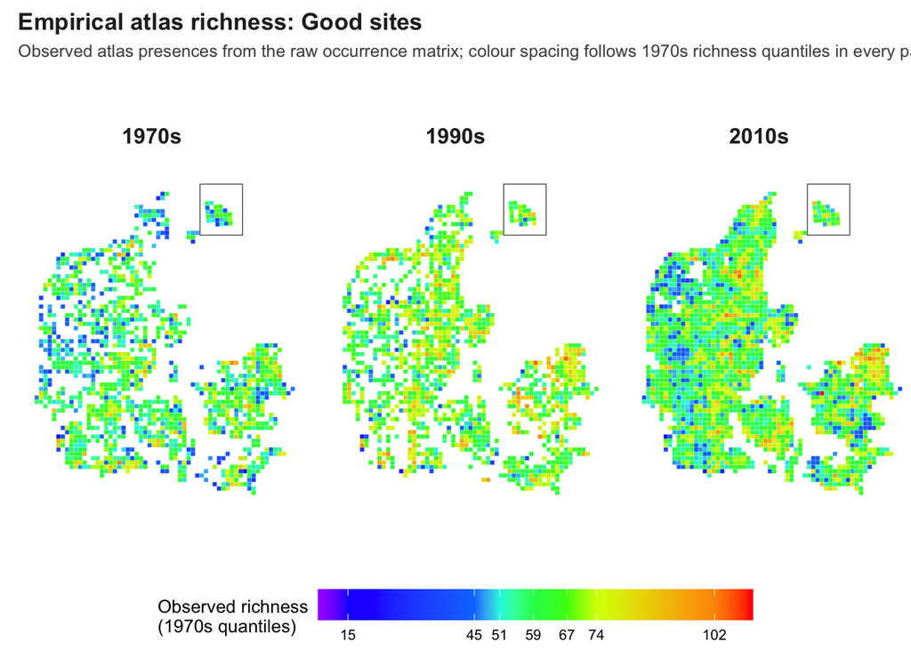

### Richness On Shared Good Sites

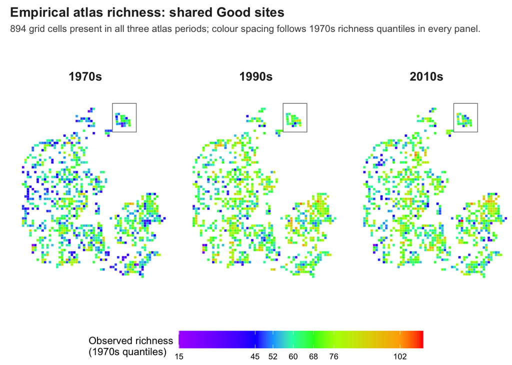

### Delta Richness On Shared Good Sites

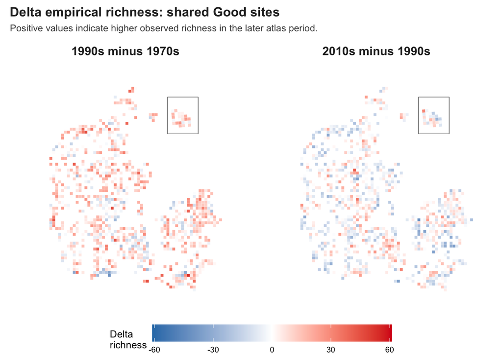

### Species-Level Changes

For this `Good` analysis, the 10 percentage-point rule corresponds to about 90 shared grid cells.

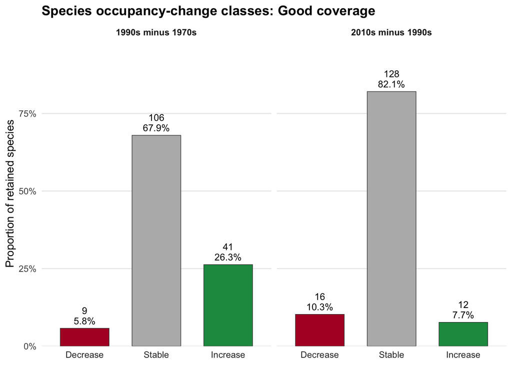

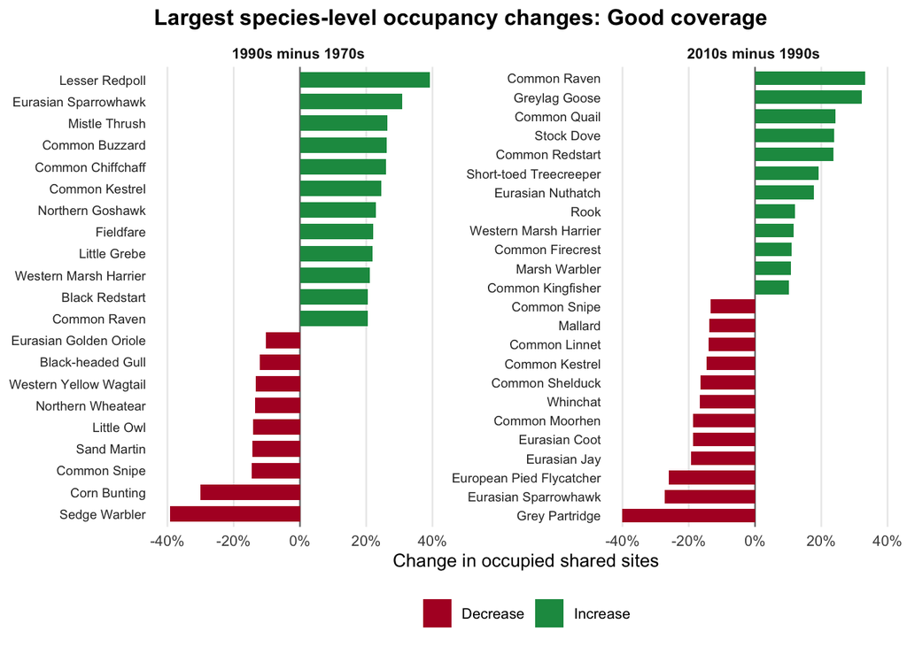

### Foraging-Guild Changes

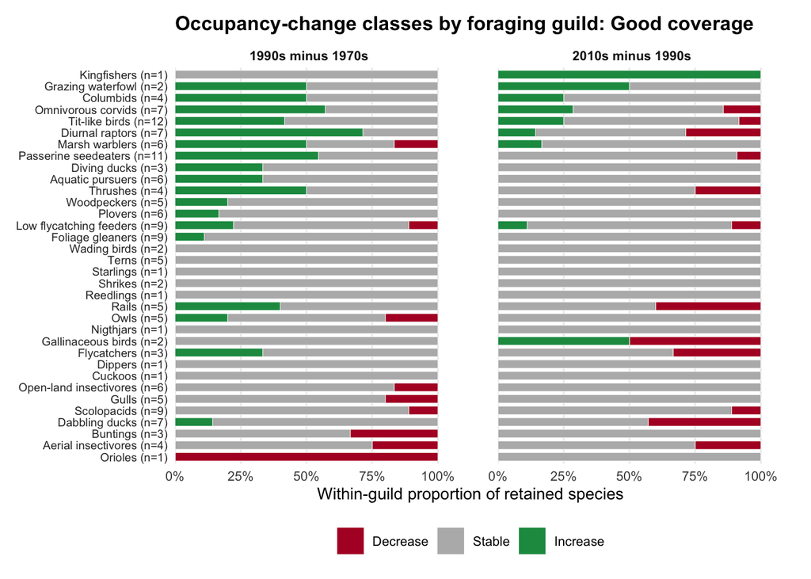